# UniversityRankings

Here we analyze the University rankings.

## H0 : Sample mean for publications for countrieswith top world rank >= population μ for Publications for all countries

## Ha : Sample mean for publications for countries with top world rank < population μ for Publications for all countries

Refer section Hypothesis test after regression models.

[figure not shown]

From the rankings we can see that India is not in the big league. We believe that for India to be in the big league ie the top numbers, there has to be some factor Indian universities have to work on so that India clinches the top spots.

We propose that publications by faculty is an important factor in world rankings. Our null hypothesis is that publications by faculty is not an important factor in world rankings. Our alternare hypothesis is that publications by faculty is an important factor in world rankings.

Multiple models will be created and one will be selected. It will be applied to a few countries individually for further insights

Multiple models will be created and one will be selected. It will be applied to a few countries individually for further insights

```python
import numpy as np
import pandas as pd
import statistics
pd.set_option('display.max_rows', 20)
pd.set_option('display.max_columns', 200)
universityrankings  = pd.read_excel('/home/shyam/MyML/universityrankings/University Rankings.xlsx',encoding='utf-8')
N = len(universityrankings.index)
universityrankings.shape
```

```
(2200, 14)
```

University Rankings

```python
universityrankings
```

|  | world_rank | institution | country | national_rank | quality_of_education | alumni_employment | quality_of_faculty | publications | influence | citations | broad_impact | patents | score | year |
| --- | --- | --- | --- | --- | --- | --- | --- | --- | --- | --- | --- | --- | --- | --- |
| 0 | 1 | Harvard University | USA | 1 | 7 | 9 | 1 | 1 | 1 | 1 | NaN | 5 | 100.00 | 2012 |
| 1 | 2 | Massachusetts Institute of Technology | USA | 2 | 9 | 17 | 3 | 12 | 4 | 4 | NaN | 1 | 91.67 | 2012 |
| 2 | 3 | Stanford University | USA | 3 | 17 | 11 | 5 | 4 | 2 | 2 | NaN | 15 | 89.50 | 2012 |
| 3 | 4 | University of Cambridge | United Kingdom | 1 | 10 | 24 | 4 | 16 | 16 | 11 | NaN | 50 | 86.17 | 2012 |
| 4 | 5 | California Institute of Technology | USA | 4 | 2 | 29 | 7 | 37 | 22 | 22 | NaN | 18 | 85.21 | 2012 |
| ... | ... | ... | ... | ... | ... | ... | ... | ... | ... | ... | ... | ... | ... | ... |
| 2195 | 996 | University of the Algarve | Portugal | 7 | 367 | 567 | 218 | 926 | 845 | 812 | 969.0 | 816 | 44.03 | 2015 |
| 2196 | 997 | Alexandria University | Egypt | 4 | 236 | 566 | 218 | 997 | 908 | 645 | 981.0 | 871 | 44.03 | 2015 |
| 2197 | 998 | Federal University of Ceará | Brazil | 18 | 367 | 549 | 218 | 830 | 823 | 812 | 975.0 | 824 | 44.03 | 2015 |
| 2198 | 999 | University of A Coruña | Spain | 40 | 367 | 567 | 218 | 886 | 974 | 812 | 975.0 | 651 | 44.02 | 2015 |
| 2199 | 1000 | China Pharmaceutical University | China | 83 | 367 | 567 | 218 | 861 | 991 | 812 | 981.0 | 547 | 44.02 | 2015 |

2200 rows × 14 columns

Indian Universities

```python
INDIA=universityrankings[universityrankings.country=='India']
INDIA
```

|  | world_rank | institution | country | national_rank | quality_of_education | alumni_employment | quality_of_faculty | publications | influence | citations | broad_impact | patents | score | year |
| --- | --- | --- | --- | --- | --- | --- | --- | --- | --- | --- | --- | --- | --- | --- |
| 527 | 328 | Indian Institute of Technology Delhi | India | 1 | 355 | 57 | 210 | 644 | 928 | 800 | 756.0 | 426 | 46.10 | 2014 |
| 635 | 436 | University of Delhi | India | 2 | 263 | 88 | 210 | 701 | 732 | 800 | 769.0 | 637 | 45.40 | 2014 |
| 700 | 501 | Indian Institute of Science | India | 3 | 355 | 478 | 210 | 305 | 495 | 609 | 472.0 | 280 | 45.11 | 2014 |
| 734 | 535 | Indian Institute of Technology Bombay | India | 4 | 355 | 478 | 210 | 522 | 785 | 609 | 724.0 | 121 | 45.00 | 2014 |
| 742 | 543 | Panjab University | India | 5 | 332 | 212 | 210 | 708 | 722 | 363 | 569.0 | 737 | 44.97 | 2014 |
| ... | ... | ... | ... | ... | ... | ... | ... | ... | ... | ... | ... | ... | ... | ... |
| 1976 | 777 | Jawaharlal Nehru Centre for Advanced Scientifi... | India | 12 | 367 | 567 | 218 | 868 | 650 | 645 | 715.0 | 453 | 44.27 | 2015 |
| 2050 | 851 | All India Institute of Medical Sciences, New D... | India | 13 | 367 | 567 | 218 | 887 | 886 | 645 | 781.0 | 839 | 44.18 | 2015 |
| 2090 | 891 | University of Calcutta | India | 14 | 140 | 346 | 209 | 964 | 900 | 645 | 994.0 | 424 | 44.14 | 2015 |
| 2122 | 923 | Jadavpur University | India | 15 | 367 | 515 | 218 | 849 | 991 | 428 | 886.0 | 735 | 44.11 | 2015 |
| 2124 | 925 | University of Hyderabad | India | 16 | 367 | 567 | 218 | 879 | 910 | 812 | 880.0 | 871 | 44.11 | 2015 |

31 rows × 14 columns

Chinese Universities

```python
China=universityrankings[universityrankings.country=='China']
China
```

|  | world_rank | institution | country | national_rank | quality_of_education | alumni_employment | quality_of_faculty | publications | influence | citations | broad_impact | patents | score | year |
| --- | --- | --- | --- | --- | --- | --- | --- | --- | --- | --- | --- | --- | --- | --- |
| 254 | 55 | Peking University | China | 1 | 355 | 35 | 210 | 65 | 155 | 250 | 155.0 | 7 | 55.30 | 2014 |
| 286 | 87 | Tsinghua University | China | 2 | 294 | 63 | 210 | 79 | 192 | 134 | 162.0 | 16 | 52.60 | 2014 |
| 388 | 189 | Fudan University | China | 3 | 355 | 126 | 210 | 120 | 264 | 310 | 230.0 | 100 | 48.14 | 2014 |
| 394 | 195 | Shanghai Jiao Tong University | China | 4 | 325 | 149 | 210 | 102 | 250 | 250 | 234.0 | 138 | 48.02 | 2014 |
| 405 | 206 | Zhejiang University | China | 5 | 355 | 293 | 210 | 86 | 318 | 493 | 290.0 | 94 | 47.76 | 2014 |
| ... | ... | ... | ... | ... | ... | ... | ... | ... | ... | ... | ... | ... | ... | ... |
| 2183 | 984 | Zhejiang University of Technology | China | 79 | 367 | 567 | 218 | 858 | 991 | 812 | 958.0 | 672 | 44.04 | 2015 |
| 2189 | 990 | Henan Normal University | China | 80 | 367 | 567 | 218 | 959 | 991 | 812 | 958.0 | 871 | 44.04 | 2015 |
| 2190 | 991 | Xidian University | China | 81 | 367 | 542 | 218 | 830 | 974 | 812 | 984.0 | 434 | 44.03 | 2015 |
| 2192 | 993 | Southwest Jiaotong University | China | 82 | 367 | 327 | 218 | 937 | 962 | 812 | 998.0 | 861 | 44.03 | 2015 |
| 2199 | 1000 | China Pharmaceutical University | China | 83 | 367 | 567 | 218 | 861 | 991 | 812 | 981.0 | 547 | 44.02 | 2015 |

167 rows × 14 columns

American universities

```python
Usa=universityrankings[universityrankings.country=='USA']
Usa
```

|  | world_rank | institution | country | national_rank | quality_of_education | alumni_employment | quality_of_faculty | publications | influence | citations | broad_impact | patents | score | year |
| --- | --- | --- | --- | --- | --- | --- | --- | --- | --- | --- | --- | --- | --- | --- |
| 0 | 1 | Harvard University | USA | 1 | 7 | 9 | 1 | 1 | 1 | 1 | NaN | 5 | 100.00 | 2012 |
| 1 | 2 | Massachusetts Institute of Technology | USA | 2 | 9 | 17 | 3 | 12 | 4 | 4 | NaN | 1 | 91.67 | 2012 |
| 2 | 3 | Stanford University | USA | 3 | 17 | 11 | 5 | 4 | 2 | 2 | NaN | 15 | 89.50 | 2012 |
| 4 | 5 | California Institute of Technology | USA | 4 | 2 | 29 | 7 | 37 | 22 | 22 | NaN | 18 | 85.21 | 2012 |
| 5 | 6 | Princeton University | USA | 5 | 8 | 14 | 2 | 53 | 33 | 26 | NaN | 101 | 82.50 | 2012 |
| ... | ... | ... | ... | ... | ... | ... | ... | ... | ... | ... | ... | ... | ... | ... |
| 2100 | 901 | University of Southern Mississippi | USA | 225 | 367 | 567 | 218 | 913 | 853 | 812 | 850.0 | 676 | 44.13 | 2015 |
| 2105 | 906 | Oakland University | USA | 226 | 367 | 567 | 218 | 888 | 810 | 812 | 850.0 | 871 | 44.13 | 2015 |
| 2112 | 913 | University of North Dakota | USA | 227 | 367 | 567 | 218 | 917 | 731 | 812 | 867.0 | 606 | 44.12 | 2015 |
| 2128 | 929 | University of Texas at El Paso | USA | 228 | 367 | 442 | 218 | 910 | 838 | 812 | 906.0 | 706 | 44.10 | 2015 |
| 2135 | 936 | University of California, Merced | USA | 229 | 367 | 567 | 218 | 899 | 540 | 812 | 906.0 | 491 | 44.09 | 2015 |

573 rows × 14 columns

Model 1 Linear regression of world university rankings Regressand world_rank with Regressors : quality_of_education + alumni_employment + quality_of_faculty + publications + influence + citations + patents

```python
import scipy.stats as stats
# get ANOVA table as R like output
import statsmodels.api as sm
from statsmodels.formula.api import ols
import statsmodels.api as sm
from patsy import dmatrices
vars = ['world_rank', 'quality_of_education', 'alumni_employment', 'quality_of_faculty','publications','influence','citations','patents']#, 'Wealth', 'Region']
universityrankings[vars]
#Relation between BMI and other variables - BPMeds + prevalentStroke + currentSmoker + glucose + age
y, X = dmatrices('world_rank  ~ quality_of_education + alumni_employment + quality_of_faculty + publications + influence + citations + patents', data=universityrankings, return_type='dataframe')
mod = sm.OLS(y, X)    # Describe model
res = mod.fit()       # Fit model
print(res.summary())   # Summarize model
```

```
                            OLS Regression Results
==============================================================================
Dep. Variable:             world_rank   R-squared:                       0.919
Model:                            OLS   Adj. R-squared:                  0.918
Method:                 Least Squares   F-statistic:                     3530.
Date:                Sun, 19 Jul 2020   Prob (F-statistic):               0.00
Time:                        17:04:48   Log-Likelihood:                -12943.
No. Observations:                2200   AIC:                         2.590e+04
Df Residuals:                    2192   BIC:                         2.595e+04
Df Model:                           7
Covariance Type:            nonrobust
========================================================================================
                           coef    std err          t      P>|t|      [0.025      0.975]
----------------------------------------------------------------------------------------
Intercept              -52.6402      5.670     -9.284      0.000     -63.759     -41.522
quality_of_education     0.0961      0.027      3.603      0.000       0.044       0.148
alumni_employment        0.2630      0.013     19.503      0.000       0.237       0.289
quality_of_faculty      -0.1890      0.050     -3.746      0.000      -0.288      -0.090
publications             0.4223      0.014     29.545      0.000       0.394       0.450
influence                0.2857      0.014     19.858      0.000       0.257       0.314
citations                0.1494      0.014     10.365      0.000       0.121       0.178
patents                  0.0886      0.010      9.283      0.000       0.070       0.107
==============================================================================
Omnibus:                      563.944   Durbin-Watson:                   1.385
Prob(Omnibus):                  0.000   Jarque-Bera (JB):             2672.471
Skew:                          -1.142   Prob(JB):                         0.00
Kurtosis:                       7.892   Cond. No.                     3.48e+03
==============================================================================

Warnings:
[1] Standard Errors assume that the covariance matrix of the errors is correctly specified.
[2] The condition number is large, 3.48e+03. This might indicate that there are
strong multicollinearity or other numerical problems.
```

Analysis:

- 91% of world ranking is explained by those variables (drawback : very high numbers of predictors is given here)
- Omnibus value should be closer to 0. Here it is far away from 0.
- Probability of Omnibus indicates residuals are not normally distributed
- Skew is between the range of -2 to +2 but kurtosis is beyond the range of -7 to +7
- Durbin Watson expeccted is between 1 and 2.
- Jacque Berra is a confirmation of the Omnibus test. So kurtosis and skew need to be studied
- Condition Number indicates sensitivity of output to input - should ideally be within 30. Here the values 3.48+03 is 3480 This implies (pending analysis of kurtosis and skew) that the data is very higly dependent on inputs.

ŷ = -52.6402+ 0.0961 quality_of_education + 0.2630 alumni_employment - 0.1890 quality_of_faculty + 0.4223 publications + 0.2857 influence + 0.1494 citations + 0.0886 patents

Here quality_of_faculty drops off from the equation because of the negative coefficient. We will take the variable with the most significant coefficient (publications) for our next analysis. Influence is the next important variable after publications and ideally both publications and influence should be used to identify world rank.

However we will leave out influence for the time being.

R-squared: 0.919

Prob (F-statistic): 0

Zero so this implies that overall the regression is meaningful.

AIC: 2.590e+04 BIC: 2.595e+04

Since the AIC (Akaike's Information Criteria) is higher, it implies there might be a better model.

Prob(Omnibus): 0

Durbin-Watson: 1.385

This is a test of autocorrelation - whether variance in errors is constant. The preferred range is 1-2. This means positive autocorrelation

Prob(JB): 00

Confirms the Prob(Omnibus)

Kurtosis: 7.892

Kurtosis implies data might not be normally distributed.

Skew: -1.142

Data is highly skewed

Cond. No. 3.48e+03

Tests the sensitivity of a function's output to its input. Idea value is within 30. Here the output is highly dependent. Very high multi collinearity.

So as discussed, the ideal approach is to take most important parameter publications and second most influence. But we will proceed only with publications

Model 2 World Rank predicted by publications

```python
import scipy.stats as stats
# get ANOVA table as R like output
import statsmodels.api as sm
from statsmodels.formula.api import ols
import statsmodels.api as sm
from patsy import dmatrices
vars = ['world_rank', 'quality_of_education', 'alumni_employment', 'quality_of_faculty','publications','influence','citations','patents']#, 'Wealth', 'Region']
universityrankings[vars]
#Relation between BMI and other variables - BPMeds + prevalentStroke + currentSmoker + glucose + age
y, X = dmatrices('world_rank  ~  publications  ', data=universityrankings, return_type='dataframe')
mod = sm.OLS(y, X)    # Describe model
res = mod.fit()       # Fit model
print(res.summary())   # Summarize model
```

```
                            OLS Regression Results
==============================================================================
Dep. Variable:             world_rank   R-squared:                       0.852
Model:                            OLS   Adj. R-squared:                  0.852
Method:                 Least Squares   F-statistic:                 1.265e+04
Date:                Sun, 19 Jul 2020   Prob (F-statistic):               0.00
Time:                        17:04:54   Log-Likelihood:                -13599.
No. Observations:                2200   AIC:                         2.720e+04
Df Residuals:                    2198   BIC:                         2.721e+04
Df Model:                           1
Covariance Type:            nonrobust
================================================================================
                   coef    std err          t      P>|t|      [0.025      0.975]
--------------------------------------------------------------------------------
Intercept       34.2956      4.531      7.569      0.000      25.410      43.181
publications     0.9247      0.008    112.486      0.000       0.909       0.941
==============================================================================
Omnibus:                      381.096   Durbin-Watson:                   1.618
Prob(Omnibus):                  0.000   Jarque-Bera (JB):             1918.071
Skew:                          -0.729   Prob(JB):                         0.00
Kurtosis:                       7.336   Cond. No.                     1.00e+03
==============================================================================

Warnings:
[1] Standard Errors assume that the covariance matrix of the errors is correctly specified.
[2] The condition number is large,  1e+03. This might indicate that there are
strong multicollinearity or other numerical problems.
```

R-squared: 0.852

85.2% of all variation in world rank can be predicted by publications

Prob (F-statistic): 0

Zero so this implies that overall the regression is meaningful.

AIC: 2.720e+04 BIC: 2.721e+04

Since the AIC (Akaike's Information Criteria) is higher, it implies there might be a better model.

Prob(Omnibus): 0

This is a test of autocorrelation - whether variance in errors is constant. The preferred range is 1-2. This means positive autocorrelation

Increase in publications will increase world rank

Prob(JB): 00

Confirms the Prob(Omnibus)

Kurtosis: 7.336

Kurtosis implies data might not be normally distributed.

Skew: -0.729

Data is negatively skewed Cond. No. 1.00e+03

Tests the sensitivity of a function's output to its input. Idea value is within 30. Here the output is highly dependent.

Model 3 world rank preicted by publications and citations

```python
import scipy.stats as stats
# get ANOVA table as R like output
import statsmodels.api as sm
from statsmodels.formula.api import ols
import statsmodels.api as sm
from patsy import dmatrices
vars = ['world_rank', 'quality_of_education', 'alumni_employment', 'quality_of_faculty','publications','influence','citations','patents']#, 'Wealth', 'Region']
universityrankings[vars]
#Relation between BMI and other variables - BPMeds + prevalentStroke + currentSmoker + glucose + age
y, X = dmatrices('world_rank  ~  publications + citations ', data=universityrankings, return_type='dataframe')
mod = sm.OLS(y, X)    # Describe model
res = mod.fit()       # Fit model
print(res.summary())   # Summarize model
```

```
                            OLS Regression Results
==============================================================================
Dep. Variable:             world_rank   R-squared:                       0.878
Model:                            OLS   Adj. R-squared:                  0.878
Method:                 Least Squares   F-statistic:                     7930.
Date:                Sun, 19 Jul 2020   Prob (F-statistic):               0.00
Time:                        17:05:00   Log-Likelihood:                -13384.
No. Observations:                2200   AIC:                         2.677e+04
Df Residuals:                    2197   BIC:                         2.679e+04
Df Model:                           2
Covariance Type:            nonrobust
================================================================================
                   coef    std err          t      P>|t|      [0.025      0.975]
--------------------------------------------------------------------------------
Intercept        7.0958      4.294      1.652      0.099      -1.325      15.517
publications     0.6829      0.013     51.101      0.000       0.657       0.709
citations        0.3348      0.015     21.806      0.000       0.305       0.365
==============================================================================
Omnibus:                      621.365   Durbin-Watson:                   1.605
Prob(Omnibus):                  0.000   Jarque-Bera (JB):             3696.410
Skew:                          -1.195   Prob(JB):                         0.00
Kurtosis:                       8.883   Cond. No.                     1.38e+03
==============================================================================

Warnings:
[1] Standard Errors assume that the covariance matrix of the errors is correctly specified.
[2] The condition number is large, 1.38e+03. This might indicate that there are
strong multicollinearity or other numerical problems.
```

ŷ = 7.0958+0.6829publications + 0.3348 citations

If publications = 0 and citations = 0 predicted number for world rank = 7.0958. 0.6829 suggests if publications increase by 1%, overall world rank will increase by 68.29% which suggests that this area of investigation for improving India's rank is very useful.

Also keeping publications out, if citations increase by 1%, overall world rank will improve by 33.48%

R-squared: 0.878

Prob (F-statistic): 0

Zero so this implies that overall the regression is meaningful.

AIC: 2.677e+04 BIC: 2.679e+04

Since the AIC (Akaike's Information Criteria) is higher, it implies there might be a better model.

Prob(Omnibus): 0

Durbin-Watson: 1.605

This is a test of autocorrelation - whether variance in errors is constant. The preferred range is 1-2. This means positive autocorrelation

Increase in publications and citations will increase world rank

Prob(JB): 00

Confirms the Prob(Omnibus)

Kurtosis: 8.883

Kurtosis implies data might not be normally distributed.

Skew: -1.195

Data is negatively skewed Cond. No. 1.38e+03

Tests the sensitivity of a function's output to its input. Idea value is within 30. Here the output is highly dependent

Model 4 adding influence

```python
import scipy.stats as stats
# get ANOVA table as R like output
import statsmodels.api as sm
from statsmodels.formula.api import ols
import statsmodels.api as sm
from patsy import dmatrices
vars = ['world_rank', 'quality_of_education', 'alumni_employment', 'quality_of_faculty','publications','influence','citations','patents']#, 'Wealth', 'Region']
universityrankings[vars]
#Relation between BMI and other variables - BPMeds + prevalentStroke + currentSmoker + glucose + age
y, X = dmatrices('world_rank  ~  publications + influence + citations ', data=universityrankings, return_type='dataframe')
mod = sm.OLS(y, X)    # Describe model
res = mod.fit()       # Fit model
print(res.summary())   # Summarize model
```

```
                            OLS Regression Results
==============================================================================
Dep. Variable:             world_rank   R-squared:                       0.894
Model:                            OLS   Adj. R-squared:                  0.893
Method:                 Least Squares   F-statistic:                     6145.
Date:                Sun, 19 Jul 2020   Prob (F-statistic):               0.00
Time:                        17:05:06   Log-Likelihood:                -13237.
No. Observations:                2200   AIC:                         2.648e+04
Df Residuals:                    2196   BIC:                         2.650e+04
Df Model:                           3
Covariance Type:            nonrobust
================================================================================
                   coef    std err          t      P>|t|      [0.025      0.975]
--------------------------------------------------------------------------------
Intercept        0.7425      4.033      0.184      0.854      -7.167       8.652
publications     0.5244      0.015     34.108      0.000       0.494       0.555
influence        0.2848      0.016     17.720      0.000       0.253       0.316
citations        0.2098      0.016     13.111      0.000       0.178       0.241
==============================================================================
Omnibus:                      749.873   Durbin-Watson:                   1.621
Prob(Omnibus):                  0.000   Jarque-Bera (JB):             4803.473
Skew:                          -1.455   Prob(JB):                         0.00
Kurtosis:                       9.628   Cond. No.                     1.73e+03
==============================================================================

Warnings:
[1] Standard Errors assume that the covariance matrix of the errors is correctly specified.
[2] The condition number is large, 1.73e+03. This might indicate that there are
strong multicollinearity or other numerical problems.
```

ŷ = 0.7425+0.5244publications + 0.2848 influence + 0.2098 citations

If publications = 0 and citations = 0 and influence = 0 predicted number for world rank is almost 0 . 0.5244 suggests if publications increase by 1%, overall world rank will increase by 52.44% which suggests that this area of investigation for improving India's rank is very useful.

Also keeping publications out, if influence increase by 1%, overall world rank will improve by 28.48%

Also keeping publications and influence out, if citations increase by 1%, overall world rank will improve by 20.98%

R-squared: 0.894

Prob (F-statistic): 0

Zero so this implies that overall the regression is meaningful.

AIC: 2.648e+04 BIC: 2.650e+04

Since the AIC (Akaike's Information Criteria) is higher, it implies there might be a better model.

Prob(Omnibus): 0

Durbin-Watson: 1.621

This is a test of autocorrelation - whether variance in errors is constant. The preferred range is 1-2. This means positive autocorrelation

Increase in publications,influence and citations will increase world rank

Prob(JB): 00

Confirms the Prob(Omnibus)

Kurtosis: 9.628

Kurtosis implies data might not be normally distributed.

Skew: -1.455

Data is negatively skewed

Cond. No. 1.73e+03

Tests the sensitivity of a function's output to its input. Idea value is within 30. Here the output is highly dependent

Model 5 also includes alumni_employment

```python
import scipy.stats as stats
# get ANOVA table as R like output
import statsmodels.api as sm
from statsmodels.formula.api import ols
import statsmodels.api as sm
from patsy import dmatrices
vars = ['world_rank', 'quality_of_education', 'alumni_employment', 'quality_of_faculty','publications','influence','citations','patents']#, 'Wealth', 'Region']
universityrankings[vars]
#Relation between BMI and other variables - BPMeds + prevalentStroke + currentSmoker + glucose + age
y, X = dmatrices('world_rank  ~  publications + influence + citations + alumni_employment', data=universityrankings, return_type='dataframe')
mod = sm.OLS(y, X)    # Describe model
res = mod.fit()       # Fit model
print(res.summary())   # Summarize model
```

```
                            OLS Regression Results
==============================================================================
Dep. Variable:             world_rank   R-squared:                       0.915
Model:                            OLS   Adj. R-squared:                  0.915
Method:                 Least Squares   F-statistic:                     5891.
Date:                Sun, 19 Jul 2020   Prob (F-statistic):               0.00
Time:                        17:05:11   Log-Likelihood:                -12992.
No. Observations:                2200   AIC:                         2.599e+04
Df Residuals:                    2195   BIC:                         2.602e+04
Df Model:                           4
Covariance Type:            nonrobust
=====================================================================================
                        coef    std err          t      P>|t|      [0.025      0.975]
-------------------------------------------------------------------------------------
Intercept           -52.3320      4.263    -12.274      0.000     -60.693     -43.971
publications          0.4586      0.014     32.657      0.000       0.431       0.486
influence             0.2900      0.014     20.164      0.000       0.262       0.318
citations             0.1511      0.015     10.390      0.000       0.123       0.180
alumni_employment     0.2946      0.013     23.390      0.000       0.270       0.319
==============================================================================
Omnibus:                      504.056   Durbin-Watson:                   1.416
Prob(Omnibus):                  0.000   Jarque-Bera (JB):             2141.860
Skew:                          -1.047   Prob(JB):                         0.00
Kurtosis:                       7.357   Cond. No.                     2.20e+03
==============================================================================

Warnings:
[1] Standard Errors assume that the covariance matrix of the errors is correctly specified.
[2] The condition number is large, 2.2e+03. This might indicate that there are
strong multicollinearity or other numerical problems.
```

ŷ = -52.3320+0.4586publications + 0.2900 influence + 0.1511 citations + 0.2946 alumni_employment

Also keeping publications out, if influence increase by 1%, overall world rank will improve by 29%

Also keeping publications and influence out, if citations increase by 1%, overall world rank will improve by 15.11%

Also keeping publications, influence and citations out, if alumni placements increase by 1%, overall world rank will improve by 29.46%

R-squared: 0.915 (also adjusted R squared)

Prob (F-statistic): 0

Zero so this implies that overall the regression is meaningful.

AIC: 2.599e+04 BIC: 2.602e+04

Since the AIC (Akaike's Information Criteria) is higher, it implies there might be a better model.

Prob(Omnibus): 0

Durbin-Watson: 1.416

This is a test of autocorrelation - whether variance in errors is constant. The preferred range is 1-2. This means positive autocorrelation

Increase in publications,influence and citations will increase world rank

Prob(JB): 00

Confirms the Prob(Omnibus)

Kurtosis: 7.357

Kurtosis implies data might not be normally distributed.

Skew: -1.047

Data is negatively skewed

Cond. No. 2.20e+03

Tests the sensitivity of a function's output to its input. Idea value is within 30. Here the output is highly dependent

```python
import scipy.stats as stats
# get ANOVA table as R like output
import statsmodels.api as sm
from statsmodels.formula.api import ols
import statsmodels.api as sm
from patsy import dmatrices
vars = ['world_rank', 'quality_of_education', 'alumni_employment', 'quality_of_faculty','publications','influence','citations','patents']#, 'Wealth', 'Region']
universityrankings[vars]
#Relation between BMI and other variables - BPMeds + prevalentStroke + currentSmoker + glucose + age
y, X = dmatrices('world_rank  ~  publications + influence + citations + alumni_employment', data=Usa, return_type='dataframe')
mod = sm.OLS(y, X)    # Describe model
res = mod.fit()       # Fit model
print(res.summary())   # Summarize model
```

```
                            OLS Regression Results
==============================================================================
Dep. Variable:             world_rank   R-squared:                       0.929
Model:                            OLS   Adj. R-squared:                  0.929
Method:                 Least Squares   F-statistic:                     1864.
Date:                Sun, 19 Jul 2020   Prob (F-statistic):               0.00
Time:                        17:05:17   Log-Likelihood:                -3259.7
No. Observations:                 573   AIC:                             6529.
Df Residuals:                     568   BIC:                             6551.
Df Model:                           4
Covariance Type:            nonrobust
=====================================================================================
                        coef    std err          t      P>|t|      [0.025      0.975]
-------------------------------------------------------------------------------------
Intercept           -22.6922      5.136     -4.418      0.000     -32.781     -12.604
publications          0.3931      0.031     12.778      0.000       0.333       0.454
influence             0.2455      0.033      7.343      0.000       0.180       0.311
citations             0.2252      0.028      8.163      0.000       0.171       0.279
alumni_employment     0.2061      0.019     10.820      0.000       0.169       0.244
==============================================================================
Omnibus:                      124.576   Durbin-Watson:                   1.613
Prob(Omnibus):                  0.000   Jarque-Bera (JB):              372.498
Skew:                          -1.035   Prob(JB):                     1.30e-81
Kurtosis:                       6.364   Cond. No.                     1.26e+03
==============================================================================

Warnings:
[1] Standard Errors assume that the covariance matrix of the errors is correctly specified.
[2] The condition number is large, 1.26e+03. This might indicate that there are
strong multicollinearity or other numerical problems.
```

India

```python
import scipy.stats as stats
# get ANOVA table as R like output
import statsmodels.api as sm
from statsmodels.formula.api import ols
import statsmodels.api as sm
from patsy import dmatrices
vars = ['world_rank', 'quality_of_education', 'alumni_employment', 'quality_of_faculty','publications','influence','citations','patents']#, 'Wealth', 'Region']
universityrankings[vars]
#Relation between BMI and other variables - BPMeds + prevalentStroke + currentSmoker + glucose + age
y, X = dmatrices('world_rank  ~  publications + influence + citations + alumni_employment', data=INDIA, return_type='dataframe')
mod = sm.OLS(y, X)    # Describe model
res = mod.fit()       # Fit model
print(res.summary())   # Summarize model
```

```
                            OLS Regression Results
==============================================================================
Dep. Variable:             world_rank   R-squared:                       0.858
Model:                            OLS   Adj. R-squared:                  0.836
Method:                 Least Squares   F-statistic:                     39.30
Date:                Sun, 19 Jul 2020   Prob (F-statistic):           1.15e-10
Time:                        17:05:22   Log-Likelihood:                -173.62
No. Observations:                  31   AIC:                             357.2
Df Residuals:                      26   BIC:                             364.4
Df Model:                           4
Covariance Type:            nonrobust
=====================================================================================
                        coef    std err          t      P>|t|      [0.025      0.975]
-------------------------------------------------------------------------------------
Intercept          -123.3218     88.970     -1.386      0.177    -306.202      59.558
publications          0.3659      0.086      4.256      0.000       0.189       0.543
influence             0.3411      0.104      3.269      0.003       0.127       0.556
citations            -0.0461      0.087     -0.531      0.600      -0.225       0.132
alumni_employment     0.7570      0.087      8.736      0.000       0.579       0.935
==============================================================================
Omnibus:                        2.192   Durbin-Watson:                   2.383
Prob(Omnibus):                  0.334   Jarque-Bera (JB):                1.949
Skew:                          -0.579   Prob(JB):                        0.377
Kurtosis:                       2.590   Cond. No.                     8.88e+03
==============================================================================

Warnings:
[1] Standard Errors assume that the covariance matrix of the errors is correctly specified.
[2] The condition number is large, 8.88e+03. This might indicate that there are
strong multicollinearity or other numerical problems.
```

China

```python
import scipy.stats as stats
# get ANOVA table as R like output
import statsmodels.api as sm
from statsmodels.formula.api import ols
import statsmodels.api as sm
from patsy import dmatrices
vars = ['world_rank', 'quality_of_education', 'alumni_employment', 'quality_of_faculty','publications','influence','citations','patents']#, 'Wealth', 'Region']
universityrankings[vars]
#Relation between BMI and other variables - BPMeds + prevalentStroke + currentSmoker + glucose + age
y, X = dmatrices('world_rank  ~  publications + influence + citations + alumni_employment', data=China, return_type='dataframe')
mod = sm.OLS(y, X)    # Describe model
res = mod.fit()       # Fit model
print(res.summary())   # Summarize model
```

```
                            OLS Regression Results
==============================================================================
Dep. Variable:             world_rank   R-squared:                       0.910
Model:                            OLS   Adj. R-squared:                  0.908
Method:                 Least Squares   F-statistic:                     411.9
Date:                Sun, 19 Jul 2020   Prob (F-statistic):           9.55e-84
Time:                        17:05:25   Log-Likelihood:                -968.42
No. Observations:                 167   AIC:                             1947.
Df Residuals:                     162   BIC:                             1962.
Df Model:                           4
Covariance Type:            nonrobust
=====================================================================================
                        coef    std err          t      P>|t|      [0.025      0.975]
-------------------------------------------------------------------------------------
Intercept           -60.7229     27.253     -2.228      0.027    -114.539      -6.907
publications          0.6563      0.042     15.519      0.000       0.573       0.740
influence             0.0012      0.048      0.025      0.980      -0.093       0.095
citations             0.3154      0.045      6.983      0.000       0.226       0.405
alumni_employment     0.3992      0.050      7.982      0.000       0.300       0.498
==============================================================================
Omnibus:                       19.335   Durbin-Watson:                   1.563
Prob(Omnibus):                  0.000   Jarque-Bera (JB):               43.885
Skew:                          -0.475   Prob(JB):                     2.95e-10
Kurtosis:                       5.325   Cond. No.                     5.50e+03
==============================================================================

Warnings:
[1] Standard Errors assume that the covariance matrix of the errors is correctly specified.
[2] The condition number is large, 5.5e+03. This might indicate that there are
strong multicollinearity or other numerical problems.
```

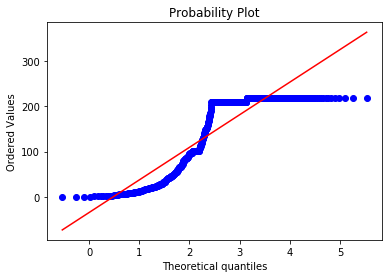

```python
import matplotlib.pyplot as plt
import numpy as np
import scipy.stats as stats
stats.probplot(Usa['quality_of_faculty'], dist='norm', sparams=(2.5,), plot=plt)
plt.show()
```

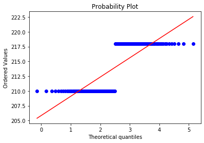

```python
import matplotlib.pyplot as plt
import numpy as np
import scipy.stats as stats
stats.probplot(China['quality_of_faculty'], dist='norm', sparams=(2.5,), plot=plt)
plt.show()
```

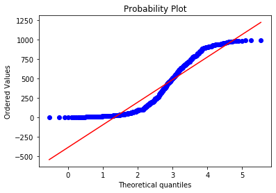

```python
import matplotlib.pyplot as plt
import numpy as np
import scipy.stats as stats
stats.probplot(Usa['publications'], dist='norm', sparams=(2.5,), plot=plt)
plt.show()
```

## H0 : Sample mean for publications for countrieswith top world rank >= population μ for Publications for all countries

## Ha : Sample mean for publications for countries with top world rank < population μ for Publications for all countries

```python
Mean = universityrankings['publications'].mean(axis = 0)
Mean
```

```
459.9086363636364
```

```python
INDIA_Pub = INDIA['publications'].mean(axis = 0)
INDIA_Pub
```

```
676.0
```

```python
China_Pub = China['publications'].mean(axis = 0)
China_Pub
```

```
588.5688622754491
```

```python
Usa_Pub = Usa['publications'].mean(axis = 0)
Usa_Pub
```

```
339.5671902268761
```

```python
import math
#calculate population standard deviation for publications
#difference of each number from mean
a = universityrankings['publications']-Mean
#square
b  = a * a
#mean of the squares is the variance
c = b.mean(axis=0)
#stddev is sqrt of variance
σ= math.sqrt(c)
σ
```

```
303.6913075625471
```

```python
UsaN = len(Usa['publications'].index)
UsaN
```

```
573
```

```python
#import statistics
#univankingsmode= statistics.mode(universityrankings['publications'])
#univankingsmode
```

```python
stddev = statistics.stdev(universityrankings['publications'])
stddev
```

```
303.76035185298394
```

```python
INDIAstddev = statistics.stdev(INDIA['publications'])
INDIAstddev
```

```
182.69993614302845
```

```python
Chinastddev = statistics.stdev(China['publications'])
Chinastddev
```

```
268.1520985192248
```

```python
Usastddev = statistics.stdev(Usa['publications'])
Usastddev
```

```
310.034057071178
```

```python
N = len(universityrankings['publications'].index)
N
```

```
2200
```

```python
NIndia = len(INDIA['publications'].index)
NIndia
```

```
31
```

```python
NChina = len(China['publications'].index)
NChina
```

```
167
```

```python
NUsa = len(Usa['publications'].index)
NUsa
```

```
573
```

The data is skewed so Mean may not be ideal . For example using mean, you will see z scores showing India doing better.

```python
zINDIA = (INDIA_Pub - Mean)/(σ/math.sqrt(N))
zINDIA
```

```
33.374624571794406
```

```python
zChina = (China_Pub - Mean)/(σ/math.sqrt(N))
zChina
```

```
19.871163126884056
```

```python
zUsa = (Usa_Pub - Mean)/(σ/math.sqrt(N))
zUsa
```

```
-18.58635402014431
```

## USA : p score < a - so Null hypothesis rejected. Alternate hypothesis accepted : USA is on top world ranks because Probability of z score of the difference between its mean and Population mean for publications

## China : p score > a - Null hypothesis can not be rejected.

## INDIA : p score > a - Null hypothesis can not be rejected.

## Hence the role of publications viz. hypothesis test and regression

[figure not shown]

Other analysis

```python
len(Usa['publications'].index)
```

```
573
```

```python
len(INDIA['publications'].index)
```

```
31
```

```python
len(China['publications'].index)
```

```
167
```

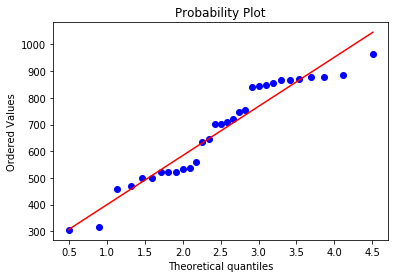

```python
import matplotlib.pyplot as plt
import numpy as np
import scipy.stats as stats
stats.probplot(INDIA['publications'], dist='norm', sparams=(2.5,), plot=plt)
plt.show()
```

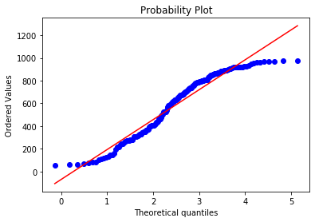

```python
import matplotlib.pyplot as plt
import numpy as np
import scipy.stats as stats
stats.probplot(China['publications'], dist='norm', sparams=(2.5,), plot=plt)
plt.show()
```

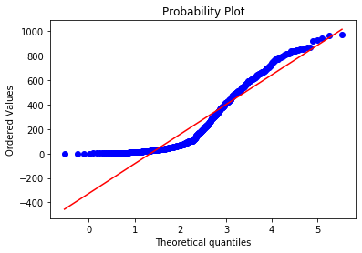

```python
import matplotlib.pyplot as plt
import numpy as np
import scipy.stats as stats
stats.probplot(Usa['influence'], dist='norm', sparams=(2.5,), plot=plt)
plt.show()
```

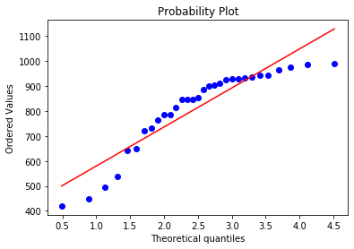

```python
import matplotlib.pyplot as plt
import numpy as np
import scipy.stats as stats
stats.probplot(INDIA['influence'], dist='norm', sparams=(2.5,), plot=plt)
plt.show()
```

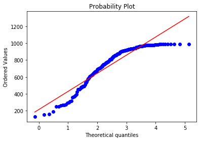

```python
import matplotlib.pyplot as plt
import numpy as np
import scipy.stats as stats
stats.probplot(China['influence'], dist='norm', sparams=(2.5,), plot=plt)
plt.show()
```

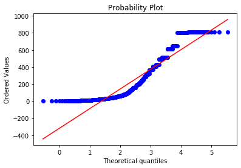

```python
import matplotlib.pyplot as plt
import numpy as np
import scipy.stats as stats
stats.probplot(Usa['citations'], dist='norm', sparams=(2.5,), plot=plt)
plt.show()
```

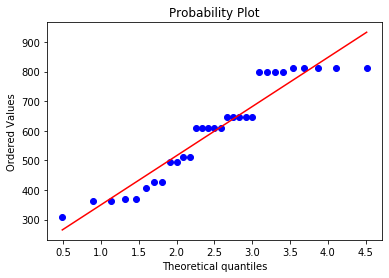

```python
import matplotlib.pyplot as plt
import numpy as np
import scipy.stats as stats
stats.probplot(INDIA['citations'], dist='norm', sparams=(2.5,), plot=plt)
plt.show()
```

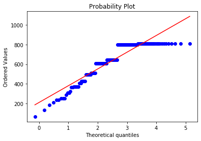

```python
import matplotlib.pyplot as plt
import numpy as np
import scipy.stats as stats
stats.probplot(China['citations'], dist='norm', sparams=(2.5,), plot=plt)
plt.show()
```

Conclusion:

Rankings in India are not predicted by citations. So Indian universities will need to work more on having more citations so that it can improve university rankings

[figure not shown]